# Graph Mining Project par Fatma Zahra Zakhama

## **Data Cleaning**

```python
fix_users_age = userData[userData.Age > 0]
fix_users_age = userData[userData.Age < 100]
userData['Age'].fillna(fix_users_age['Age'].mean())
userData = userData[userData.Age < 101]
userData = userData[userData.Age > 6]
ratingData= ratingData.drop_duplicates()
```

```python
ratings = ratingData.merge(bookData, on='ISBN')
ratings.head()
```

|  | User-ID | ISBN | Book-Rating | Book-Title | Book-Author | Year-Of-Publication | Publisher | Image-URL-S | Image-URL-M | Image-URL-L |
| --- | --- | --- | --- | --- | --- | --- | --- | --- | --- | --- |
| 0 | 276726 | 0155061224 | 5 | Rites of Passage | Judith Rae | 2001 | Heinle | http://images.amazon.com/images/P/0155061224.0... | http://images.amazon.com/images/P/0155061224.0... | http://images.amazon.com/images/P/0155061224.0... |
| 1 | 276729 | 052165615X | 3 | Help!: Level 1 | Philip Prowse | 1999 | Cambridge University Press | http://images.amazon.com/images/P/052165615X.0... | http://images.amazon.com/images/P/052165615X.0... | http://images.amazon.com/images/P/052165615X.0... |
| 2 | 276729 | 0521795028 | 6 | The Amsterdam Connection : Level 4 (Cambridge ... | Sue Leather | 2001 | Cambridge University Press | http://images.amazon.com/images/P/0521795028.0... | http://images.amazon.com/images/P/0521795028.0... | http://images.amazon.com/images/P/0521795028.0... |
| 3 | 276744 | 038550120X | 7 | A Painted House | JOHN GRISHAM | 2001 | Doubleday | http://images.amazon.com/images/P/038550120X.0... | http://images.amazon.com/images/P/038550120X.0... | http://images.amazon.com/images/P/038550120X.0... |
| 4 | 11676 | 038550120X | 10 | A Painted House | JOHN GRISHAM | 2001 | Doubleday | http://images.amazon.com/images/P/038550120X.0... | http://images.amazon.com/images/P/038550120X.0... | http://images.amazon.com/images/P/038550120X.0... |

```python
ratings = ratings[ratings['ISBN'].str.contains(r'^\d+$|^\d+X$')]
ratings['ISBN'] = ratings['ISBN'].replace({'X':''}, regex=True).astype(np.int64)
```

```python
user_node =ratings['User-ID'].unique()
book_node =ratings['Book-Title'].unique()
```

```python
ratings = ratings[["User-ID","Book-Title","Book-Rating","ISBN"]]
ratings20 = ratings.head(20)
ratings20.head()
```

|  | User-ID | Book-Title | Book-Rating | ISBN |
| --- | --- | --- | --- | --- |
| 0 | 276726 | Rites of Passage | 5 | 155061224 |
| 1 | 276729 | Help!: Level 1 | 3 | 52165615 |
| 2 | 276729 | The Amsterdam Connection : Level 4 (Cambridge ... | 6 | 521795028 |
| 3 | 276744 | A Painted House | 7 | 38550120 |
| 4 | 11676 | A Painted House | 10 | 38550120 |

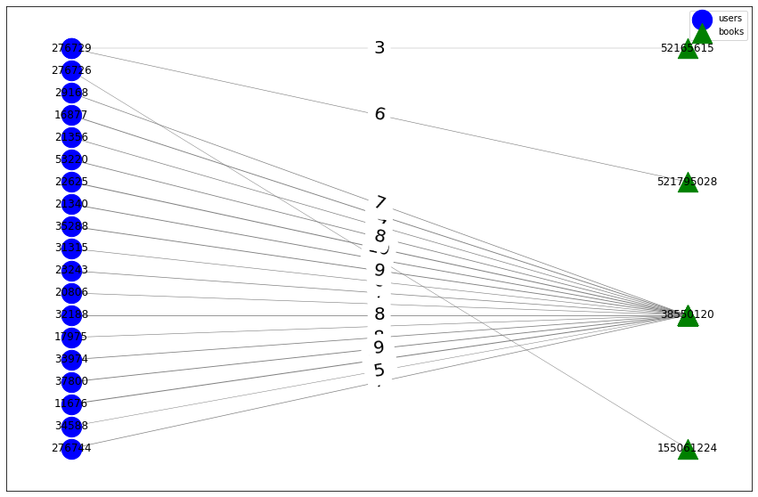

```python
G = nx.Graph()
user_nodes=list(ratings20['User-ID'])
book_nodes=list(ratings20['ISBN'])
# Add nodes with the node attribute "bipartite"

G.add_nodes_from(user_nodes, bipartite=0)
G.add_nodes_from(book_nodes, bipartite=1)


weights = []
for index, row in ratings20.iterrows():
    G.add_edge(row["User-ID"], row["ISBN"], weight=row["Book-Rating"])
    weights.append(row["Book-Rating"])
bipartite.is_bipartite(G)

zip_list=list(zip(user_nodes,book_nodes))
dict_of_labels = dict()
for i in range(len(zip_list)):
    dict_of_labels[zip_list[i]]=weights[i]

plt.figure(figsize=(15, 10))

pos = nx.bipartite_layout(G, user_nodes)

# Draw the graph
nx.draw_networkx_nodes(G, pos, nodelist=user_nodes, node_color='blue', node_shape='o', label='users', node_size=500)
nx.draw_networkx_nodes(G, pos, nodelist=book_nodes, node_color='green', node_shape='^', label='books',node_size=500)
nx.draw_networkx_edges(G, pos, edge_color='gray', width=[d['weight']*0.1 for (u, v, d) in G.edges(data=True)])

nx.draw_networkx_edge_labels(G, pos, edge_labels=dict_of_labels, font_size=20)
nx.draw_networkx_labels(G, pos)

plt.legend()
plt.show()
```

```python
del(ratings['Book-Title'])
ratings.head()
```

|  | User-ID | Book-Rating | ISBN |
| --- | --- | --- | --- |
| 0 | 276726 | 5 | 155061224 |
| 1 | 276729 | 3 | 52165615 |
| 2 | 276729 | 6 | 521795028 |
| 3 | 276744 | 7 | 38550120 |
| 4 | 11676 | 10 | 38550120 |

```python
ratings['ISBN']=pd.factorize(ratings['ISBN'])[0] + 1
ratings['User-ID']=pd.factorize(ratings['User-ID'])[0] + 1
```

```python
ratings.describe()
```

|  | User-ID | Book-Rating | ISBN |
| --- | --- | --- | --- |
| count | 383582.000000 | 383582.000000 | 383582.000000 |
| mean | 14503.167565 | 7.626573 | 44121.395446 |
| std | 16777.815445 | 1.841473 | 42653.790501 |
| min | 1.000000 | 1.000000 | 1.000000 |
| 25% | 2028.250000 | 7.000000 | 7810.000000 |
| 50% | 7319.000000 | 8.000000 | 28660.500000 |
| 75% | 21393.000000 | 9.000000 | 73264.750000 |
| max | 68076.000000 | 10.000000 | 149601.000000 |

On va effectuer un prétraitement d'encodage pour s'assurer que user_id et ISBN sont tous deux entre 0 et unique_count afin de ne pas causer de problème de dépassement lors de l'indexation des embeddings.

```python
lbl_user = preprocessing.LabelEncoder()
lbl_book = preprocessing.LabelEncoder()
ratings=ratings[ratings["Book-Rating"]>5]
ratings["User-ID"] = lbl_user.fit_transform(ratings["User-ID"].values)
ratings["ISBN"] = lbl_book.fit_transform(ratings.ISBN.values)
```

```python
ratings.update(ratings["ISBN"] + ratings["User-ID"].max())
ratings.describe()
```

|  | User-ID | Book-Rating | ISBN |
| --- | --- | --- | --- |
| count | 321658.000000 | 321658.000000 | 321658.000000 |
| mean | 13325.067158 | 8.228242 | 99719.564593 |
| std | 15264.719977 | 1.273587 | 36857.577542 |
| min | 0.000000 | 6.000000 | 61271.000000 |
| 25% | 1950.000000 | 7.000000 | 68243.000000 |
| 50% | 6801.000000 | 8.000000 | 86293.500000 |
| 75% | 19794.750000 | 9.000000 | 125104.000000 |
| max | 61271.000000 | 10.000000 | 190069.000000 |

```python
print(ratings["User-ID"].max())
print(ratings["ISBN"].max())
```

```
61271

190069
```

```python
ratings.shape
```

```
(321658, 3)
```

```python
#import torch_geometric.data as data
#edge_index = [[int(x) for x in k] for k in dict_of_labels.keys()]
#edge_index = torch.LongTensor(edge_index)
#graph = data.Data(edge_index=edge_index, edge_attr=weights)
```

```python
!pip install --upgrade scipy networkx
```

Pour mettre en œuvre le LightGCN pour un système de recommandation, nous devons suivre les étapes générales de toute mise en œuvre de système de recommandation :

1. Préparation des données : Cela comprend le nettoyage, le prétraitement et la division des données en ensembles de formation et de test. Vous devrez également construire le graphique qui représente les relations entre les articles et les utilisateurs dans votre ensemble de données.
2. Définition du modèle : Le LightGCN est un modèle de réseau de neurones convolutif graphique (GCN). Vous devrez donc définir l'architecture des couches GCN, le nombre de couches et le nombre de neurones dans chaque couche.
3. Entraînez le modèle : Utilisez les données de formation pour former le modèle. Vous devrez utiliser l'algorithme d'entraînement approprié (tel que la descente de gradient stochastique ou Adam) et optimiser les paramètres du modèle à l'aide de la fonction de perte définie.
4. Évaluez le modèle : Utilisez les données de test pour évaluer les performances du modèle. Vous pouvez utiliser des mesures telles que la précision, le rappel et le score F1 pour évaluer les performances du modèle.
5. Affinez et améliorez le modèle : En fonction des résultats de l'évaluation, vous devrez peut-être affiner les paramètres et l'architecture du modèle pour améliorer ses performances.

```python
G = nx.Graph()
user_nodes=list(ratings['User-ID'])
book_nodes=list(ratings['ISBN'])
# Add nodes with the node attribute "bipartite"

G.add_nodes_from(user_nodes, bipartite=0)
G.add_nodes_from(book_nodes, bipartite=1)


weights = []
for index, row in ratings.iterrows():
    G.add_edge(row["User-ID"], row["ISBN"], weight=row["Book-Rating"])
    weights.append(row["Book-Rating"])
bipartite.is_bipartite(G)

zip_list=list(zip(user_nodes,book_nodes))
dict_of_labels = dict()
for i in range(len(zip_list)):
    dict_of_labels[zip_list[i]]=weights[i]
```

```python
import torch_geometric.data as data
edge_index = [[int(x) for x in k] for k in dict_of_labels.keys()]
#edge_index = torch.LongTensor(edge_index)
graph = data.Data(edge_index=edge_index, edge_attr=weights)
edge_index = torch.LongTensor(edge_index)
data = Data(edge_index=edge_index.t().contiguous(), num_nodes=len(G.nodes))
print(edge_index)
print(edge_index.size())
num_users = len(ratings['User-ID'].unique())
num_books = len(ratings['ISBN'].unique())
```

```
tensor([[     0,  61271],

        [     1,  61272],

        [     2,  61272],

        ...,

        [  7191, 190067],

        [  7191, 190068],

        [  7191, 190069]])

torch.Size([321658, 2])
```

La technique RandomLinkSplit consiste à sélectionner aléatoirement des données d'entraînement pour chaque ensemble. Cela permet de garantir que les données dans chaque ensemble sont représentatives de l'ensemble total de données d'entraînement, ce qui est important pour éviter les biais dans l'évaluation des performances du modèle.

```python
from torch_geometric.transforms import RandomLinkSplit
split = RandomLinkSplit(num_val = .1, num_test = .1, is_undirected = True, add_negative_train_samples = False, neg_sampling_ratio = 0)
train_split, val_split, test_split = split(data)
```

```python
class PlainData(Data):
    def __inc__(self, key, value, *args, **kwargs):
        return 0

class BookDataSet(Dataset):
  def __init__(self, edge_index, transform = None, pre_transform = None, pre_filter = None):
    self.edge_index = edge_index
    self.user_name = torch.unique(edge_index[0, :]).tolist()
    self.num_nodes = len(self.user_name)
    super().__init__(transform, pre_transform, pre_filter)

  def len(self):
    return self.num_nodes

  def get(self, idx):
    edge_index = self.edge_index[:, self.edge_index[0, :] == idx]
    return PlainData(edge_index = edge_index)
```

```python
train_edgeLabel = BookDataSet(edge_index = train_split.edge_label_index)
train_edge = Data(edge_index = train_split.edge_index)
```

```python
validation_edgeLabel = BookDataSet(edge_index = val_split.edge_label_index)
validation_edge = Data(edge_index = val_split.edge_index)
```

```python
from torch_geometric.loader import DataLoader
batch_size = 400
train_loader = DataLoader(train_edgeLabel, batch_size = batch_size, shuffle = True)
validation_loader = DataLoader(validation_edgeLabel, batch_size = batch_size, shuffle = False)
```

```python
train_loader.dataset
```

```
BookDataSet(53672)
```

```python
def sample_negative_edges(batch, num_users, num_nodes):
    negs = torch.randint(num_users, num_nodes, (batch.edge_index.shape[1],)) # Sample negative edges
    edge_index_negs = torch.stack([batch.edge_index[0,:], negs], dim=0) # Stack indices for negative edges
    return Data(edge_index=edge_index_negs)
```

Cette fonction, sample_negative_edges, est utilisée pour échantillonner les bords négatifs de l'ensemble de données d'apprentissage. Elle prend les entrées suivantes :

- batch : un objet PyTorch Data qui contient les arêtes positives de l'ensemble de données d'entraînement.
- num_users : le nombre d'utilisateurs dans l'ensemble de données.
- num_nodes : le nombre de noeuds dans le graphe.

Enfin, la fonction crée un nouvel objet Data PyTorch, edge_index_negs, qui contient les indices des arêtes négatives en empilant les indices des arêtes positives et des arêtes négatives stockées dans la liste negs. Elle renvoie le nouvel objet Data contenant les arêtes négatives.

Il est important de noter que cette fonction échantillonne les arêtes négatives de façon aléatoire et qu'elle n'est peut-être pas le meilleur choix pour tous les cas d'utilisation, surtout si vous avez une connaissance préalable des arêtes négatives.

La fonction train est un exemple de fonction d'entraînement pour un système de recommandation utilisant LightGCN. La fonction prend plusieurs arguments en entrée :

- model : le modèle LightGCN qui sera entraîné.
- train_loader : un objet PyTorch DataLoader qui charge les données d'entraînement par lots.
- train_edge : un tenseur clairsemé PyTorch qui stocke les données d'entraînement dans un format clairsemé.
- validation_loader : un objet PyTorch DataLoader qui charge les données de validation par lots.
- validation_edge : un tenseur clairsemé PyTorch qui stocke les données de
- validation dans un format clairsemé.
- num_nodes : le nombre de noeuds dans le graphe.
- num_users : le nombre de listes de lecture dans l'ensemble de données.
- optimizer : l'optimiseur qui sera utilisé pour mettre à jour les paramètres du modèle pendant la formation.

device : le dispositif (CPU ou GPU) sur lequel le modèle sera entraîné.

- k : le nombre de recommandations supérieures qui seront faites pour chaque liste de lecture.
- n_epochs : le nombre de fois que l'ensemble des données d'entraînement sera passé dans le modèle.

```python
import matplotlib.pyplot as plt
from sklearn.metrics import precision_recall_fscore_support

def train(model, train_loader, train_edge, validation_loader,validation_edge, num_nodes, num_users, optimizer,  k, n_epochs,device):
    train_losses = []
    validation_losses = []
    running_loss = 0.
    total_edges = 0
    train_edge = train_edge.to(device)
    validation_edge =validation_edge.to(device)
    recalls = {}


    for epoch in range(1, n_epochs + 1):

        model.train()  # Training
        total_edges = 0
        for i, batch in enumerate(train_loader):
            optimizer.zero_grad()
            negative_values = sample_negative_edges(batch, num_users, num_nodes)
            batch, negative_values = batch.to(device), negative_values.to(device)
            positive_rank = model(train_edge.edge_index, batch.edge_index)
            negative_rank = model(train_edge.edge_index, negative_values.edge_index)

            loss = model.recommendation_loss(positive_rank, negative_rank)#Calcul Loss

            loss.backward()
            optimizer.step()

            running_loss += loss.item() * positive_rank.size(0) * batch.edge_index.shape[1]
            total_edges += batch.edge_index.shape[1]
            avg_loss = running_loss / total_edges
            train_losses.append(avg_loss)
            print(f'Epoch [{epoch}/{n_epochs}] - Training loss = {avg_loss}')
            model.eval()
            with torch.no_grad():
                for j, batch in enumerate(validation_loader):
                    batch = batch.to(device)
                    TopK = model.recommend(validation_edge.edge_index, torch.unique(batch.edge_index[0, :]), torch.unique(batch.edge_index[1, :]), k)
                    # Calculating recall@k
                    unique_playlists = torch.unique(batch.edge_index[0, :])
                    for i, pidx in enumerate(unique_playlists):
                        ground_truth =validation_edge.edge_index[1,validation_edge.edge_index[0, :] == pidx].cpu()
                        preds = TopK[i].cpu()
                        if len(ground_truth) == 0:
                            recall = 0
                        else:
                            recall = len(np.intersect1d(ground_truth, preds)) / len(ground_truth)
                        recalls[pidx] = recall
                avg_val_loss = np.mean(list(recalls.values()))
                print(f'Epoch [{epoch}/{n_epochs}] - Validation recall = {avg_val_loss}')

    return print("avg_val_loss: ",avg_val_loss,"recall :",recall)
```

```python
device = torch.device('cuda') if torch.cuda.is_available() else torch.device('cpu')
from torch_geometric.nn.models import LightGCN
model = LightGCN(num_nodes = data.num_nodes, embedding_dim = 64, num_layers = 4)
model.to(device)
optimizer = torch.optim.Adam(model.parameters(), lr = 0.01)
train(model, train_loader, train_edge, validation_loader, validation_edge, data.num_nodes,num_users ,optimizer, 150, 8, device)
```

```
Epoch [1/8] - Training loss = 0.7059336758393329

Epoch [1/8] - Validation recall = 0.08703475881470188

Epoch [1/8] - Training loss = 0.7051085621523623

Epoch [1/8] - Validation recall = 0.08723110181634895

Epoch [1/8] - Training loss = 0.7038558162868345

Epoch [1/8] - Validation recall = 0.08734237959896406

Epoch [1/8] - Training loss = 0.7030323765557975

Epoch [1/8] - Validation recall = 0.08744636914421036

Epoch [1/8] - Training loss = 0.7023296616857153

Epoch [1/8] - Validation recall = 0.08753777861359702

Epoch [1/8] - Training loss = 0.7016777584532666

Epoch [1/8] - Validation recall = 0.0876648202654401

Epoch [1/8] - Training loss = 0.7009178171539363

Epoch [1/8] - Validation recall = 0.08778393762145267

Epoch [1/8] - Training loss = 0.7003226231626742

Epoch [1/8] - Validation recall = 0.08793366384111652

Epoch [1/8] - Training loss = 0.6997221134776196

Epoch [1/8] - Validation recall = 0.0881118682151744

Epoch [1/8] - Training loss = 0.6991548784208205

Epoch [1/8] - Validation recall = 0.08830844696457124

```

[output cut: 4266 more lines]

```
Epoch [8/8] - Validation recall = 0.09021669053148679

Epoch [8/8] - Training loss = 5.598459657192204

Epoch [8/8] - Validation recall = 0.09020470776438384

Epoch [8/8] - Training loss = 5.550079611382308

Epoch [8/8] - Validation recall = 0.09019294272610462

Epoch [8/8] - Training loss = 5.54567048667748

Epoch [8/8] - Validation recall = 0.09018118832633212

avg_val_loss:  0.09018118832633212 recall : 0.04
```

## *Bibliographie*

- https://www.kaggle.com/datasets/arashnic/book-recommendation-dataset
- https://medium.com/stanford-cs224w/recommender-systems-with-gnns-in-pyg-d8301178e377
- https://drive.google.com/file/d/1F0U7naTXgaquG5x2q9FjRulPXAchRkmn/view?fbclid=IwAR3XwlKsX5pusM2tbS8Ea5oW9hNJgANieF7IC0fweu2OmeEIUDLduSdYapo
- https://arxiv.org/abs/2002.02126 https://somyt536.medium.com/how-spotify-uses-machine-learning-models-to-recommend-you-the-music-you-like-332c282d7f7#:~:text=Each%20song%20is%20converted%20into,their%20listeners%20like%20listening%20to.